# Covid and vaxxination

# Load data

Data comes from [Our World In data](https://github.com/owid/covid-19-data/tree/master/public/data)’s COVID dataset. I have prepared this a little bit for you.

Let’s get started with a dataset called `cross.csv` which you find as follows

```r
cross=read.csv("https://raw.githubusercontent.com/mondpanther/datastorieshub/95d94862115819350247823f174a2633cde0236b/code/cross.csv")

names(cross) # show the names of the dataframe
```

```
##  [1] "X"                              "month"
##  [3] "iso_code"                       "date"
##  [5] "location"                       "total_cases"
##  [7] "total_deaths"                   "total_cases_per_million"
##  [9] "total_deaths_per_million"       "total_tests"
## [11] "total_tests_per_thousand"       "total_vaccinations"
## [13] "total_boosters"                 "total_vaccinations_per_hundred"
## [15] "total_boosters_per_hundred"     "population"
## [17] "population_density"             "continent"
## [19] "cs"                             "L1vax"
## [21] "vax"                            "lndeaths"
## [23] "deaths"                         "lnvax"
## [25] "period"
```

```r
head(cross)  # show the first couple of lines
```

```
##   X   month iso_code       date    location total_cases total_deaths
## 1 1 2021-11      ABW 2021-11-27       Aruba           0            0
## 2 2 2021-02      AFG 2021-02-28 Afghanistan       55714         2443
## 3 3 2021-09      AFG 2021-09-30 Afghanistan      155174         7204
## 4 4 2021-02      AGO 2021-02-28      Angola       20807          508
## 5 5 2021-05      AGO 2021-05-31      Angola       34551          766
## 6 6 2021-02      AIA 2021-02-28    Anguilla           0            0
##   total_cases_per_million total_deaths_per_million total_tests
## 1                   0.000                    0.000           0
## 2                1398.604                   61.327           0
## 3                3895.377                  180.844           0
## 4                 613.168                   14.970           0
## 5                1018.194                   22.573           0
## 6                   0.000                    0.000           0
##   total_tests_per_thousand total_vaccinations total_boosters
```

[output cut: 27 more lines]

# Let’s only take the EU & North America part of the data…

…and only for the second period…

```r
library(dplyr)
cross %>% group_by(continent) %>% summarize(n())
```

```
## # A tibble: 6 x 2
##   continent     `n()`
##   <chr>         <int>
## 1 Africa          109
## 2 Asia             94
## 3 Europe           98
## 4 North America    63
## 5 Oceania          32
## 6 South America    26
```

```r
cross %>% filter(period==1) %>%
  group_by(continent) %>%
  summarize(n())
```

```
## # A tibble: 6 x 2
##   continent     `n()`
##   <chr>         <int>
## 1 Africa           55
## 2 Asia             49
## 3 Europe           50
## 4 North America    34
## 5 Oceania          21
## 6 South America    13
```

```r
cross_euram=cross %>% filter((continent=="Europe" | continent=="North America") & period==2)
```

Start by plotting

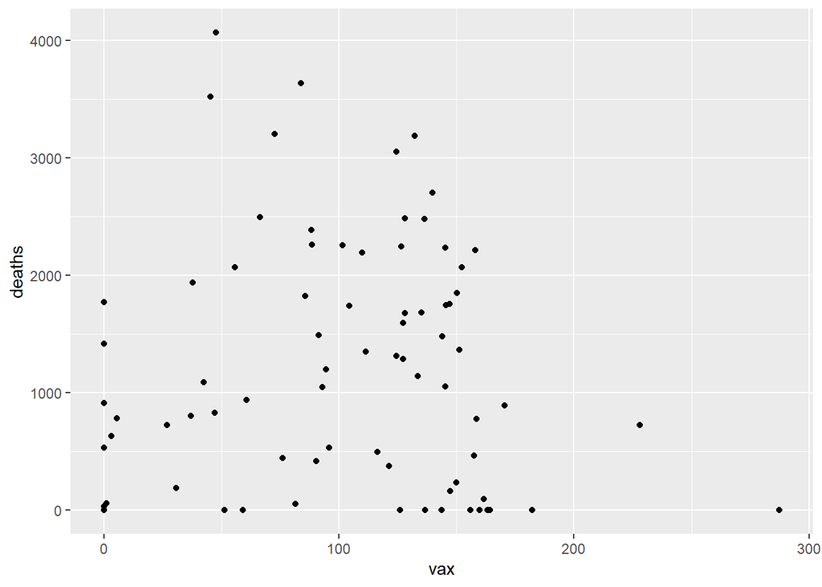

```r
library(ggplot2)
cross_euram %>% ggplot(  aes(x=vax,y=deaths)  ) + # setup the aesthetic

                       geom_point()              # use it to plot poines
```

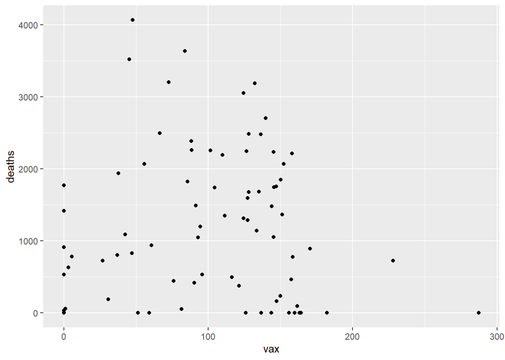

```r
# Note that above we broke the command over several lines which can be a good
# idea to make things more easily readable...however the following is exactly the same
# command:


cross_euram %>% ggplot(  aes(x=vax,y=deaths)  ) +  geom_point()
```

Let’s do that a bit nicer:

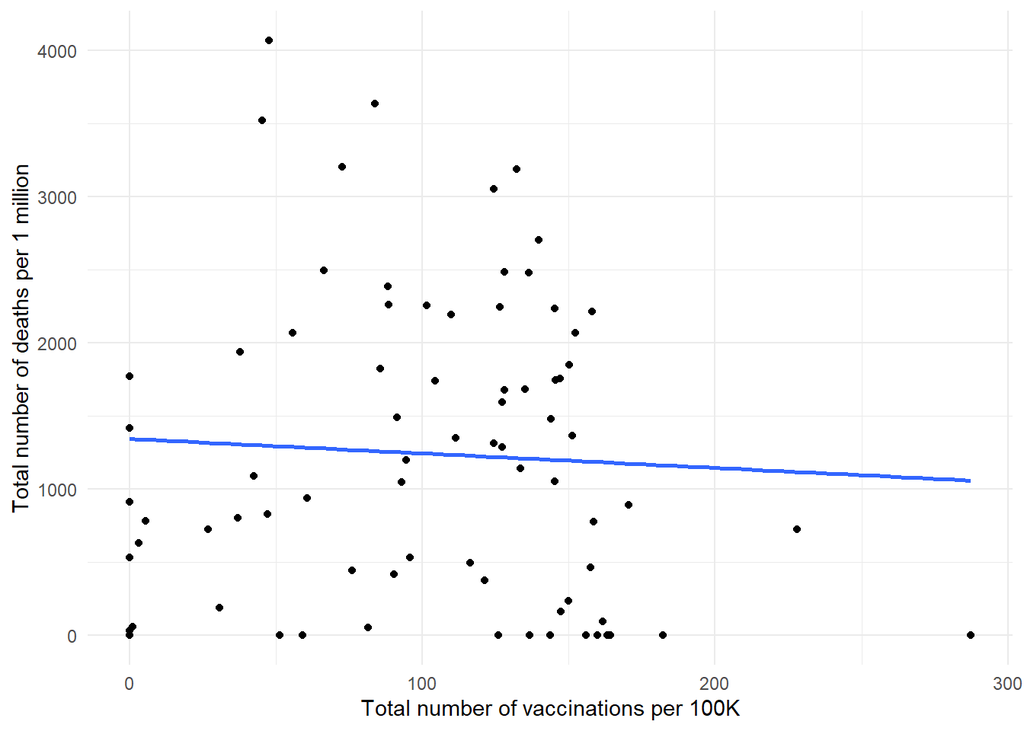

```r
cross_euram %>% ggplot(  aes(x=vax,y=deaths)  ) +
  geom_point() +
  ylab("Total number of deaths per 1 million")+
  xlab("Total number of vaccinations per 100K")+
  theme_minimal()+
  geom_smooth(method="lm",se=F)
```

Vaccines seem to be associated with less deaths. Before we discuss this more let’s work out the exact parameters of the trendline. We use the `lm` command for that:

```r
reg1=lm(formula=deaths ~ vax,data=cross_euram)

reg1 %>% summary()  # The summary command provides a nice summary
```

```
##
## Call:
## lm(formula = deaths ~ vax, data = cross_euram)
##
## Residuals:
##     Min      1Q  Median      3Q     Max
## -1344.6  -847.5  -147.3   652.7  2768.8
##
## Coefficients:
##              Estimate Std. Error t value Pr(>|t|)
## (Intercept) 1344.6381   241.7908   5.561 3.93e-07 ***
## vax           -0.9906     2.0475  -0.484     0.63
## ---
## Signif. codes:  0 '***' 0.001 '**' 0.01 '*' 0.05 '.' 0.1 ' ' 1
##
## Residual standard error: 1043 on 75 degrees of freedom
## Multiple R-squared:  0.003111,   Adjusted R-squared:  -0.01018
## F-statistic: 0.2341 on 1 and 75 DF,  p-value: 0.6299
```

An increase of 1 additional vaccination per 100K leads to 0.99 less deaths per 1 million.

Let’s look at the relationship between estimated residuals $\hat{\epsilon}$ and explanatory variable $X$; i.e. vaccination rates in our case..

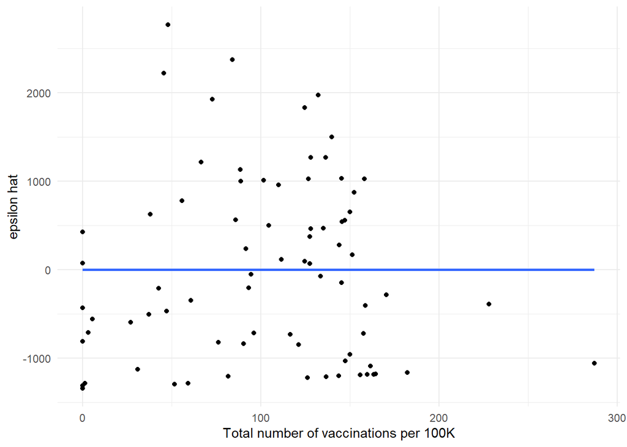

```r
cross_euram=cross_euram %>% mutate(epsilonhat=reg1$residuals)

cross_euram %>% ggplot(  aes(x=vax,y=epsilonhat)  ) +
  geom_point() +
  ylab("epsilon hat")+
  xlab("Total number of vaccinations per 100K")+
  theme_minimal()+
  geom_smooth(method="lm",se=FALSE)
```

```r
cor(cross_euram%>% select(vax,epsilonhat,deaths))
```

```
##                      vax   epsilonhat      deaths
## vax         1.000000e+00 1.138338e-16 -0.05577751
## epsilonhat  1.138338e-16 1.000000e+00  0.99844322
## deaths     -5.577751e-02 9.984432e-01  1.00000000
```

```r
cross_eur %>% ggplot(  aes(y=deaths,x=epsilonhat)  ) +
  geom_point() +
  xlab("epsilon hat")+
  ylab("Deaths")+
  theme_minimal()+
  geom_smooth(method="lm",se=FALSE)
```

[output not shown]

Is the causal effect of vaccines on detahs really that low?

The following could be going on:

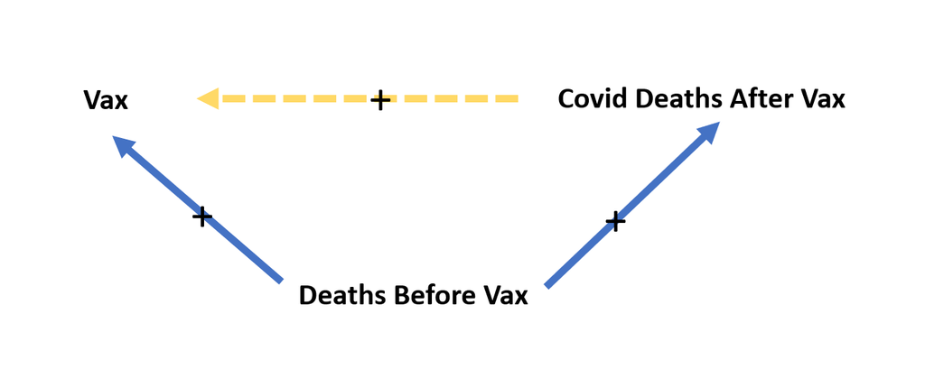

We can explore this by looking at the amount of death we had after the arrival of vaccines…

```r
cross_euram2=cross %>%
  filter(continent=="Europe" | continent =="North America") %>%  # this time we include the first period
                                    # which is from Februrary 2021
  arrange(iso_code,date) %>%        # i.e. sort
  group_by(iso_code) %>%            # put in country groups
  mutate(Ddeaths=deaths-dplyr::lag(deaths) ) # we compute the change in the death variable
```

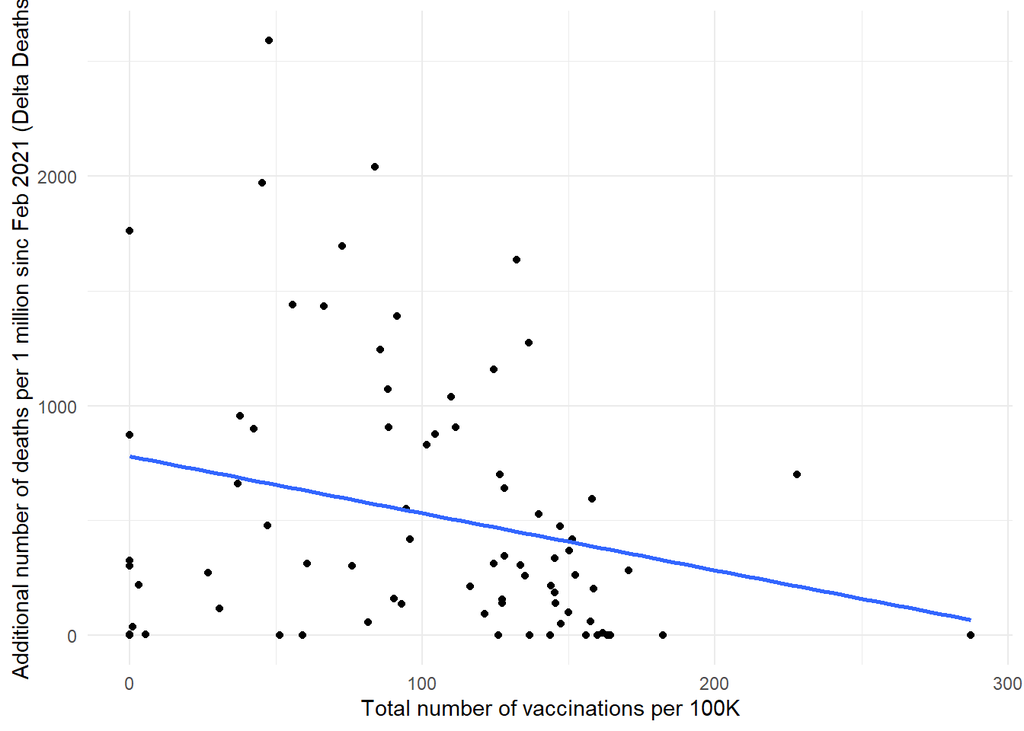

```r
cross_euram2 %>% ggplot(  aes(x=vax,y=Ddeaths)  ) +
  geom_point() +
  ylab("Additional number of deaths per 1 million sinc Feb 2021 (Delta Deaths")+
  xlab("Total number of vaccinations per 100K")+
  theme_minimal()+
  geom_smooth(method="lm",se=FALSE)
```

The same as regression:

```r
reg2=lm(formula=Ddeaths ~ vax,data=cross_euram2)

reg2 %>% summary()  # The summary command provides a nice summary
```

```
##
## Call:
## lm(formula = Ddeaths ~ vax, data = cross_euram2)
##
## Residuals:
##    Min     1Q Median     3Q    Max
## -780.0 -384.2 -159.6  268.2 1926.8
##
## Coefficients:
##             Estimate Std. Error t value Pr(>|t|)
## (Intercept)  779.965    131.365   5.937  8.4e-08 ***
## vax           -2.478      1.112  -2.228   0.0289 *
## ---
## Signif. codes:  0 '***' 0.001 '**' 0.01 '*' 0.05 '.' 0.1 ' ' 1
##
## Residual standard error: 566.7 on 75 degrees of freedom
##   (84 observations deleted due to missingness)
## Multiple R-squared:  0.06206,    Adjusted R-squared:  0.04955
## F-statistic: 4.962 on 1 and 75 DF,  p-value: 0.0289
```

i.e. an increase of 1 additional vaccination per 100K leads to 2.48 less deaths per 1 million; i.e. a much bigger effect than before.

# More Visiions

## Comparing continents

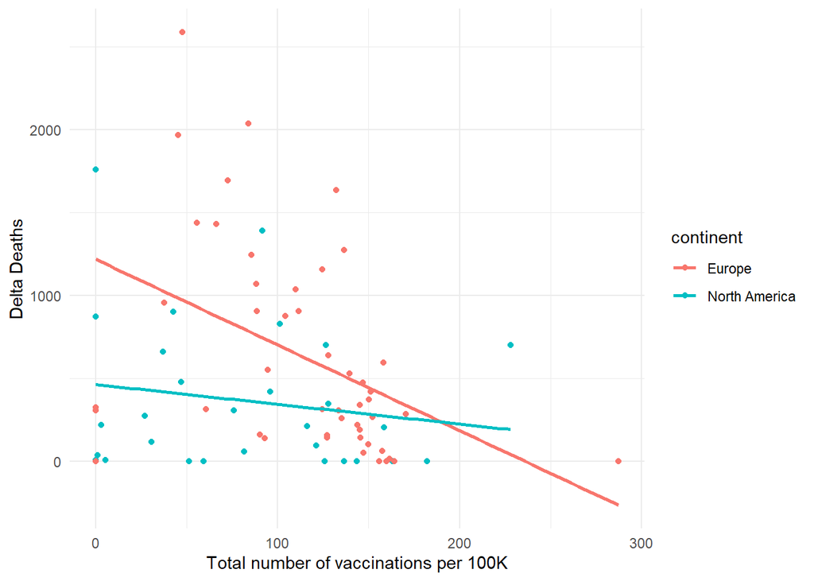

```r
cross_euram2 %>% ggplot(  aes(x=vax,y=Ddeaths, color=continent)  ) +
  geom_point() +
  ylab("Delta Deaths")+
  xlab("Total number of vaccinations per 100K")+
  theme_minimal()+
  geom_smooth(method="lm",se=FALSE)
```

Country labels?

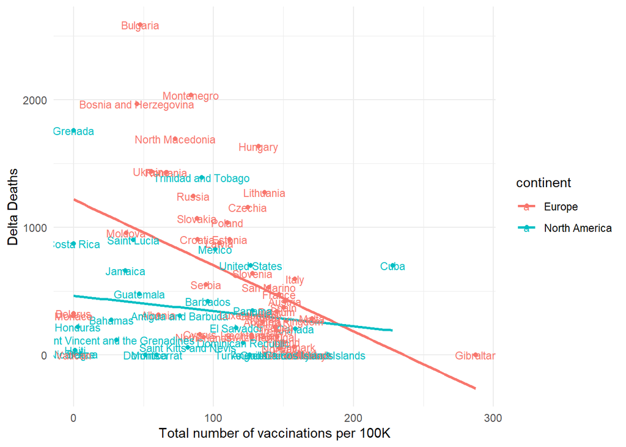

```r
cross_euram2 %>% ggplot(  aes(x=vax,y=Ddeaths, color=continent,label=location)  ) +
  geom_point() +
  ylab("Delta Deaths")+
  xlab("Total number of vaccinations per 100K")+
  theme_minimal()+
  geom_smooth(method="lm",se=FALSE)+geom_text(size=3)
```

```r
cross_euram2 =cross_euram2 %>% mutate(slabel=ifelse(population>20*10^6,location,""))


library(ggrepel)
```

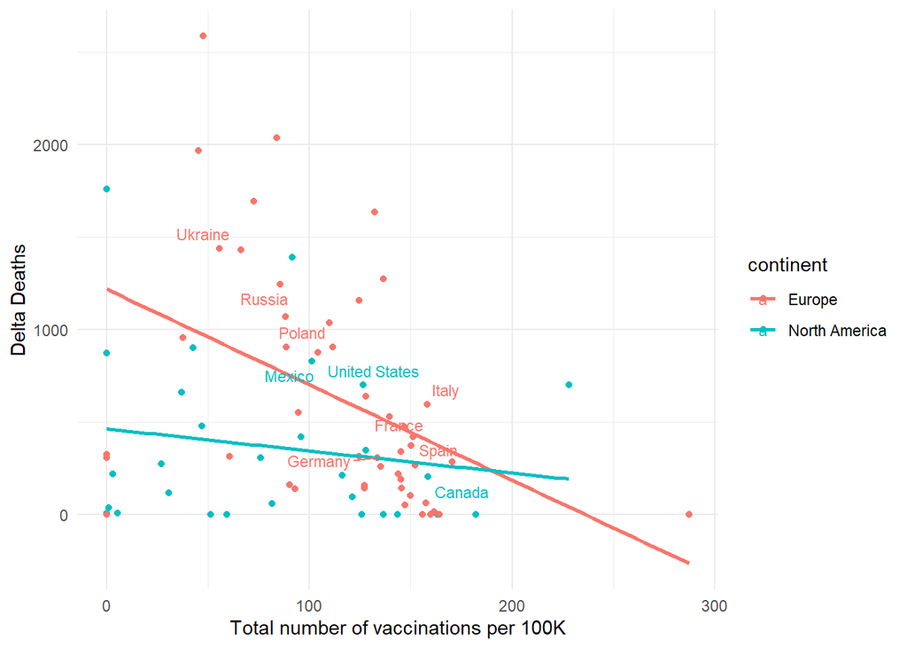

```r
cross_euram2 %>% ggplot(  aes(x=vax,y=Ddeaths, color=continent,label=slabel)  ) +
  geom_point() +
  ylab("Delta Deaths")+
  xlab("Total number of vaccinations per 100K")+
  theme_minimal()+
  geom_smooth(method="lm",se=FALSE)+geom_text_repel(size=3)
```

## Across all continents…..

An example to exmplore ggplot2

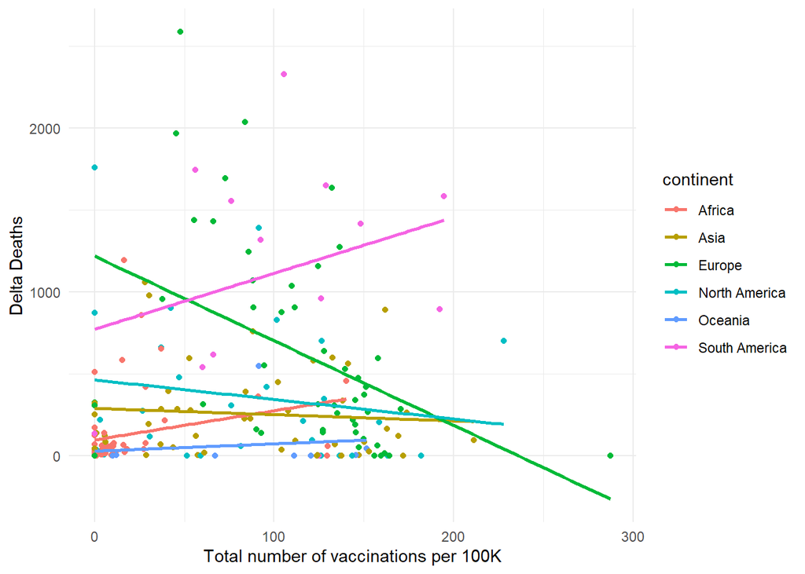

```r
cross=cross %>%
 arrange(iso_code,date) %>%        # i.e. sort
  group_by(iso_code) %>%            # put in country groups
  mutate(Ddeaths=deaths-dplyr::lag(deaths) ) # we compute the change in the death variable



cross %>% ggplot(  aes(x=vax,y=Ddeaths, color=continent)  ) +
  geom_point() +
  ylab("Delta Deaths")+
  xlab("Total number of vaccinations per 100K")+
  theme_minimal()+
  geom_smooth(method="lm",se=FALSE)
```

## Time series

```r
library(lubridate)
```

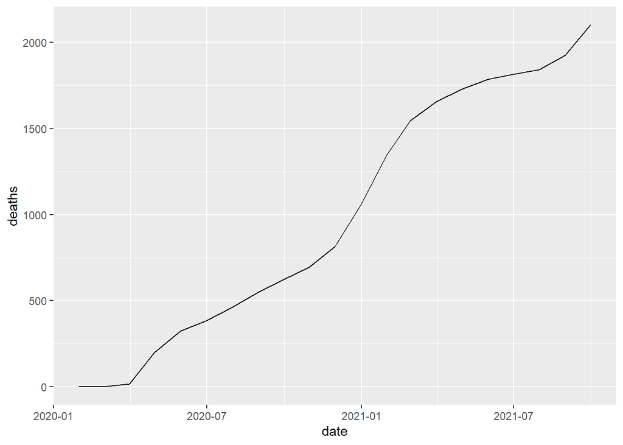

```r
dfm=read.csv("https://github.com/mondpanther/datastorieshub/raw/master/code/dfm.csv") %>%
  mutate( vax   =total_vaccinations_per_hundred,
          deaths=total_deaths_per_million)


# Tell R about the date variable
dfm_us=dfm %>% filter(iso_code=="USA")%>% mutate(date=as_date(date))


p1=dfm_us %>% ggplot(aes(x=date,y=deaths)) + geom_line()
p1
```

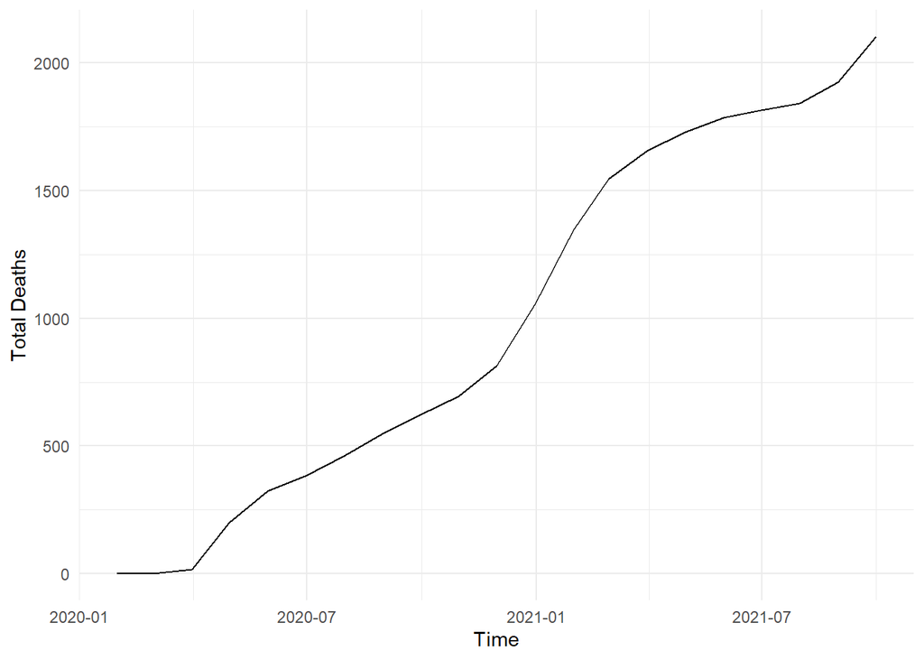

```r
p1+theme_minimal()+xlab("Time")+ylab("Total Deaths")
```

Sometimes better to look at changes:

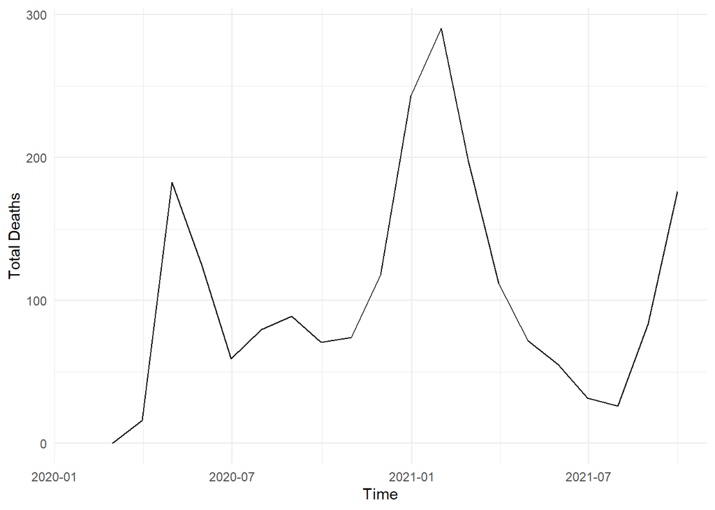

```r
dfm_us=dfm_us %>% arrange(date) %>% mutate(Ddeaths=deaths-dplyr::lag(deaths))
dfm_us %>% ggplot(aes(x=date,y=Ddeaths)) + geom_line() +
  theme_minimal()+
  xlab("Time")+ylab("Total Deaths")
```

## Histogram’s & Density plots

## Histogram

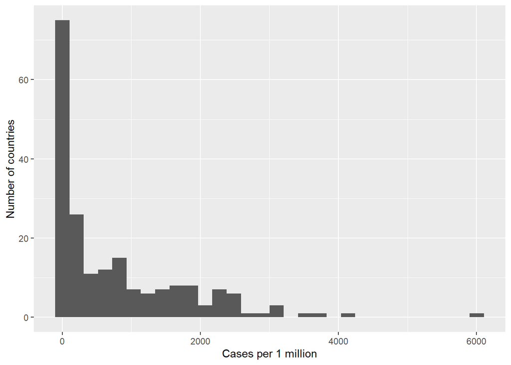

```r
crossp2=cross %>% filter(period==2)

crossp2 %>% ggplot( aes(x=deaths)) + geom_histogram() + ylab("Number of countries")+xlab("Cases per 1 million")
```

An alternative way of looking at histograms is in terms of density. If you multiply the density with the width of a histogram bin you get the share of observations (as opposed to the count) that fall into a particular category:

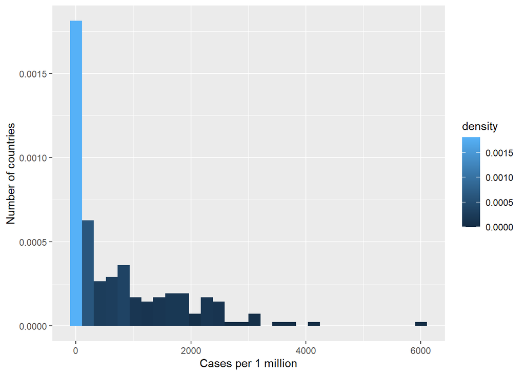

```r
d1=crossp2 %>% ggplot( aes(x=deaths)) +  geom_histogram(aes(y=..density.. ,fill=..density..))  +
  ylab("Number of countries")+xlab("Cases per 1 million")

d1
```

## Density

An outright density plot is often preferable to a histogram. It’s kind of like a density histogram where let the bins become every smaller:

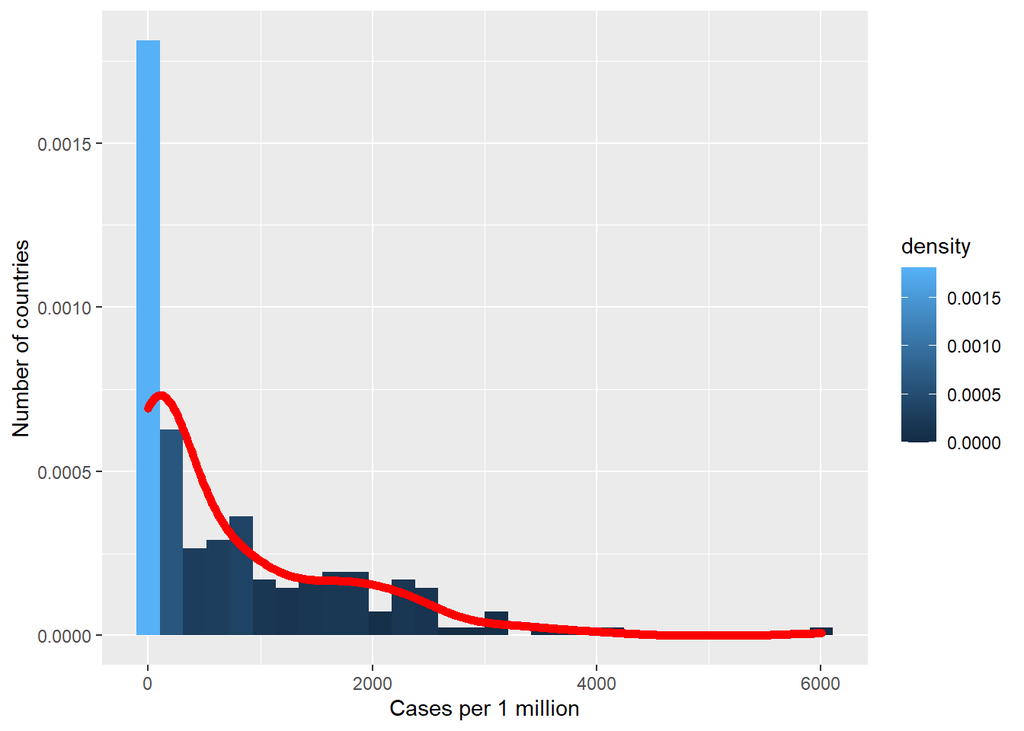

```r
d1 + geom_density(color="red",size=2)
```